# ReproducibleResearch_PeerReview01

Craig Rowley

December 6, 2014

I have something I want to show you today that I think you’ll enjoy. And it will benefit your understanding of quantified health.

Let’s start by loading our activity dataset (you’ll need to set your working directory appropriately):

```r
activity <- read.csv("activity.csv", header=TRUE ,sep=",")
rowCount <- nrow(activity)
```

17568 rows of beautiful data!

Let’s see what we’re dealing with:

```r
summary(activity)
```

```
##      steps                date          interval
##  Min.   :  0.00   2012-10-01:  288   Min.   :   0.0
##  1st Qu.:  0.00   2012-10-02:  288   1st Qu.: 588.8
##  Median :  0.00   2012-10-03:  288   Median :1177.5
##  Mean   : 37.38   2012-10-04:  288   Mean   :1177.5
##  3rd Qu.: 12.00   2012-10-05:  288   3rd Qu.:1766.2
##  Max.   :806.00   2012-10-06:  288   Max.   :2355.0
##  NA's   :2304     (Other)   :15840
```

So:

- steps is NA 13.11% of the time, and 62.69% of the populated values are 0
- date summary just gives us a view of the data… it is an ISO formatted Date
- interval summary is also odd looking in the summary

### Steps

Here’s the first question we answer:

#### What is mean total number of steps taken per day?

(For this part of the assignment, you can ignore the missing values in the dataset.)

1. Make a histogram of the total number of steps taken each day
2. Calculate and report the mean and median total number of steps taken per day

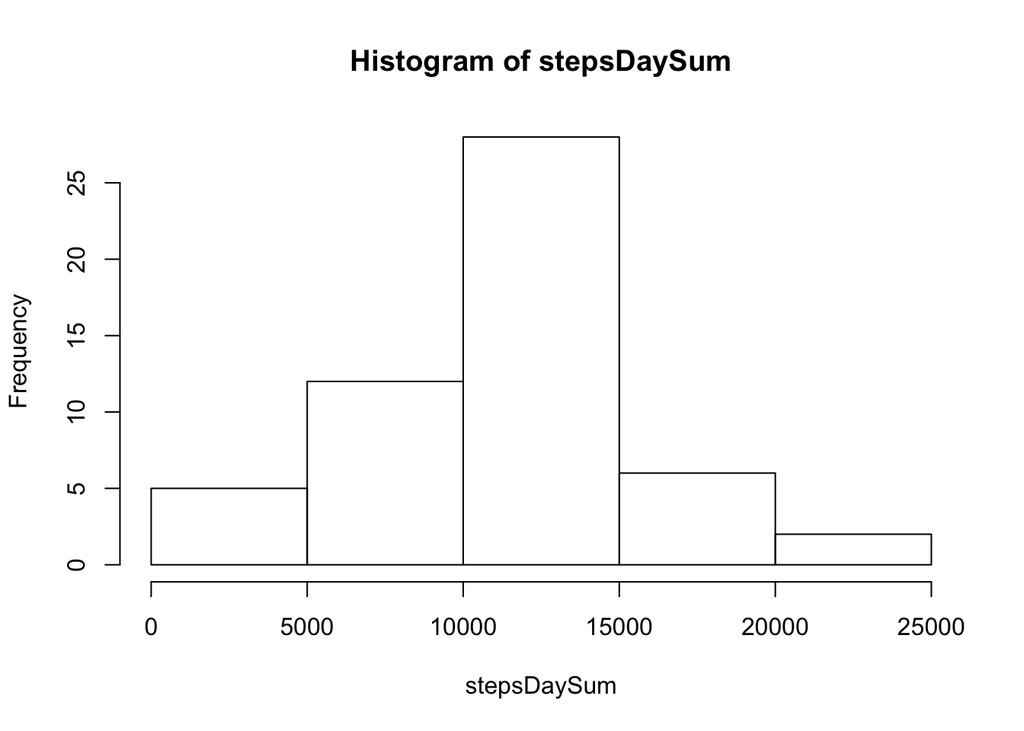

### What is the average daily activity pattern?

Make a time series plot (i.e. type = “l”) of the 5-minute interval (x-axis) and the average number of steps taken, averaged across all days (y-axis)

Which 5-minute interval, on average across all the days in the dataset, contains the maximum number of steps?

#### Answer:

1. NOTE: NA values are removed (na.rm=TRUE) when computing the mean

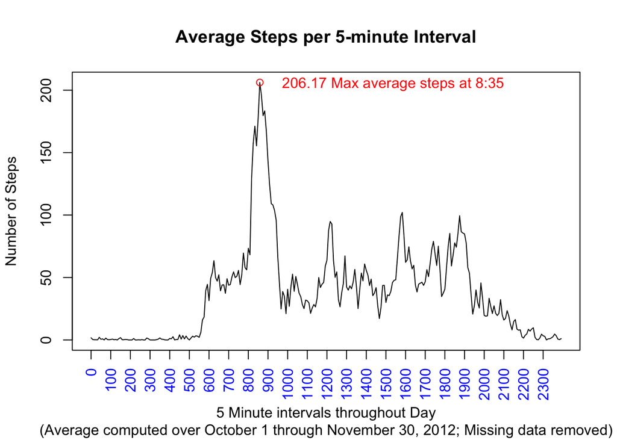

```r
meanIntervalSteps <- tapply( activity$steps, activity$interval, FUN=mean, na.rm=TRUE)
maxIntervalColumn <- sort(meanIntervalSteps,decreasing=TRUE)[1]
maxIntervalName <- names(maxIntervalColumn)
maxIntervalSteps <- maxIntervalColumn[[1]]
raw24ClockTime <- as.integer(maxIntervalName)
maxIntervalHour <- as.integer( raw24ClockTime / 100)
maxIntervalMinute <- as.integer( raw24ClockTime %% 100)

#...Show the Plot
plot(meanIntervalSteps, type="l",
     main="Average Steps per 5-minute Interval",
     sub="(Average computed over October 1 through November 30, 2012; Missing data removed)",
     xaxt="n", xlab="5 Minute intervals throughout Day",
     ylab="Number of Steps"
     )
#...X-axis labels on the hours
hourIndexes <- seq(1,length(meanIntervalSteps),12)
axis(1, at=hourIndexes, labels=names(meanIntervalSteps)[hourIndexes], col.axis="blue", las=2)
#...Label the maximum point
maxStepsColIdx <- which(names(meanIntervalSteps) == maxIntervalName)
timeString <- paste(maxIntervalHour,":",maxIntervalMinute,sep="")
text( maxStepsColIdx, maxIntervalSteps, paste(round(maxIntervalSteps,2),"Max average steps at",timeString), adj=c(-0.1,0.5), col="red" )
points( maxStepsColIdx, maxIntervalSteps, col="red")
```

The interval with the largest mean average number of steps across the entire dataset, independent of day, is 835. This corresponds to 8:35 on a 24-hour clock.

### Imputing missing values

#### Number of missing values

Note that there are a number of days/intervals where there are missing values (coded as NA). The presence of missing days may introduce bias into some calculations or summaries of the data.

Calculate and report the total number of missing values in the dataset (i.e. the total number of rows with NAs)

```r
naStepsCount <- nrow( activity[is.na(activity$steps),] )
```

Answer: Activity dataset has 2304 rows with missing step counts.

#### Imputation impact research

Devise a strategy for filling in all of the missing values in the dataset. The strategy does not need to be sophisticated. For example, you could use the mean/median for that day, or the mean for that 5-minute interval, etc.

Create a new dataset that is equal to the original dataset but with the missing data filled in.

Make a histogram of the total number of steps taken each day and Calculate and report the mean and median total number of steps taken per day. Do these values differ from the estimates from the first part of the assignment? What is the impact of imputing missing data on the estimates of the total daily number of steps?

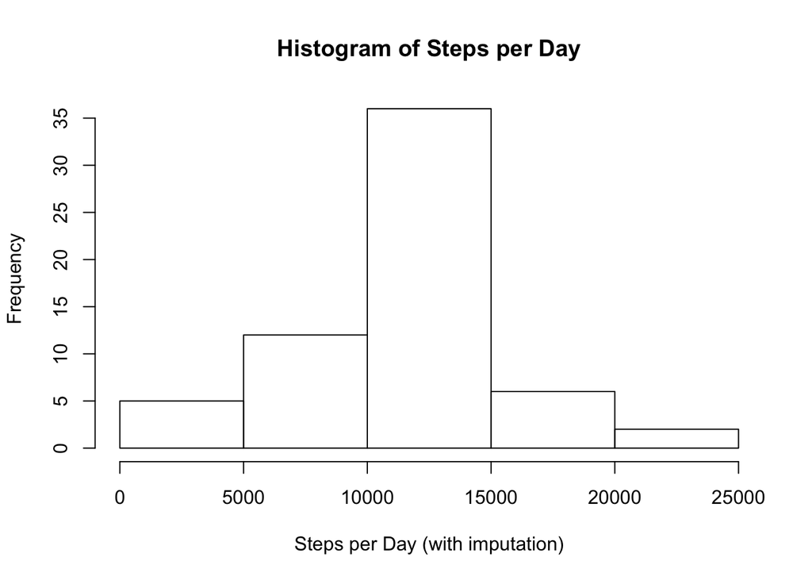

```r
#...create data.frame with average steps per interval across whole dataset
meanStepsByInterval <- data.frame( interval=names(meanIntervalSteps), avg_steps=as.numeric(as.character(meanIntervalSteps)) )
#...Inner Join the interval steps as a new column in th activity dataset
activity <- merge(activity, meanStepsByInterval, by="interval", all.x=TRUE, all.y=FALSE)
#...Create a new column that coalesces the steps with avg_steps per interval (this is our imputation)
activity$imputed_steps <- ifelse( is.na(activity$steps), activity$avg_steps, activity$steps )

#...Compute sum of steps per day
imputedStepsPerDay <- tapply( activity$imputed_steps, activity$date, FUN=sum, na.rm=TRUE)
stepsPerDay <- tapply( activity$steps, activity$date, FUN=sum, na.rm=TRUE)

#...histogram
histImputedStepsPerDay <- hist(imputedStepsPerDay, main="Histogram of Steps per Day", xlab="Steps per Day (with imputation)")
```

```r
#...mean and median steps per day (with and without imputation)
meanImputedStepsPerDay <- mean(imputedStepsPerDay)
medianImputedStepsPerDay <- median(imputedStepsPerDay)

meanStepsPerDay <- mean(stepsPerDay)
medianStepsPerDay <- median(stepsPerDay)

#...column of the maximum count so we can get the breaks
maxCol <- which(histImputedStepsPerDay$counts == max(histImputedStepsPerDay$counts), arr.ind = TRUE)
```

##### Answer:

When using the average steps per interval to impute any NA-value steps, the user took 10766 mean average steps and 10766 median average steps.

Without imputation, the user took 9354 mean average steps and 10395 median average steps.

Imputation increased the mean average steps per day by 1411 steps, and the median average steps per day by 371 steps. This increased the maximum frequency from 28 to 36 for bucket range (10000-15000).